[figure not shown]

Machine Learning  
FS 2019  
Michael Müller und Rino Gantenbein

# Machine Learning Projekt - Olympiade

## Einleitung

The Olympic Games are a worldwide sporting event, at which the best athletes in the world compete in various disciplines on behalf of their country. Its origins go back to ancient Greece.

We want to create a learner who can predict the medal winners at the next Olympic Games based on the current health, economic and educational situation of all participating countries.

With the help of such a learner one could support experts in estimating the probability of winning in individual countries and one could dispense with possible oracles such as those used at the Football World Cup.

## Datasets

We are using 2 different datasets.

The First is about the medalwinners of the last years

https://www.kaggle.com/heesoo37/120-years-of-olympic-history-athletes-and-results

and the other is about life expectancy of all countries

https://www.kaggle.com/kumarajarshi/life-expectancy-who

## Objectives and Procedure

To build a maschine learner, we...

- merge the datasets.
- clean the resultet data
- do a exploratory data analysis
- preprozess our data
- build a random forest classifier
- validate the random forest classifier
- build a adaboost classifier out of the random forest
- validate the bosted classifier
- build a K-Nearest neigthbour classifier
- validate the K-Nearest neigthbour classifer
- build a voting classifier
- validate the voting classifier
- swiss medals 2020
- conclusion

## Imports

```python
#Import Libarys
import pandas as pd
import seaborn as sns
import matplotlib.pyplot as plt
import numpy as np

import itertools
import warnings
import copy as cp

from sklearn import preprocessing

from sklearn.ensemble import RandomForestClassifier
from sklearn.ensemble import AdaBoostClassifier
from sklearn.ensemble import VotingClassifier
from sklearn.neighbors import KNeighborsClassifier

from sklearn.metrics import accuracy_score
from sklearn.metrics import classification_report
from sklearn.metrics import confusion_matrix
from sklearn.metrics import recall_score
from sklearn.metrics import f1_score

from sklearn.model_selection import GridSearchCV
from sklearn.model_selection import cross_val_predict
from sklearn.model_selection import train_test_split

#Import data
athlete_events = pd.read_csv("data/athlete_events.csv")
lifeExpectancy = pd.read_csv("data/lifeExpectancy.csv")

#Supress Warnings
warnings.simplefilter('ignore')
```

# Data preparation

## Merging

```python
#DeepCopy
olympicAthletes = cp.copy(athlete_events)

#Delete unnessesary columns
olympicAthletes = olympicAthletes.drop('Games', axis=1)
olympicAthletes = olympicAthletes.drop('ID', axis=1)
olympicAthletes = olympicAthletes.drop('Team', axis=1)
olympicAthletes = olympicAthletes.drop('City', axis=1)
olympicAthletes = olympicAthletes.drop('Sport', axis=1)

#Replace Medal NaN with 0
olympicAthletes['Medal'].fillna(0, inplace=True)

#Drop all Rows with an NaN
olympicAthletes = olympicAthletes.dropna()

#Drop all Dublicated Athletes
olympicAthletes = olympicAthletes.drop_duplicates()

#Reset Index
olympicAthletes.reset_index(inplace=True, drop=True)

#show
olympicAthletes.head(5)
```

|  | Name | Sex | Age | Height | Weight | NOC | Year | Season | Event | Medal |
| --- | --- | --- | --- | --- | --- | --- | --- | --- | --- | --- |
| 0 | A Dijiang | M | 24.0 | 180.0 | 80.0 | CHN | 1992 | Summer | Basketball Men's Basketball | 0 |
| 1 | A Lamusi | M | 23.0 | 170.0 | 60.0 | CHN | 2012 | Summer | Judo Men's Extra-Lightweight | 0 |
| 2 | Christine Jacoba Aaftink | F | 21.0 | 185.0 | 82.0 | NED | 1988 | Winter | Speed Skating Women's 500 metres | 0 |
| 3 | Christine Jacoba Aaftink | F | 21.0 | 185.0 | 82.0 | NED | 1988 | Winter | Speed Skating Women's 1,000 metres | 0 |
| 4 | Christine Jacoba Aaftink | F | 25.0 | 185.0 | 82.0 | NED | 1992 | Winter | Speed Skating Women's 500 metres | 0 |

```python
#DeepCopy list
olympicGames = cp.copy(athlete_events)

# Builds Medalcount for the events
olympicGames['MedalCount'] = np.where(olympicGames['Medal'].isna(),0,1)
olympicMedals = pd.pivot_table(olympicGames,
                               index = ['Team', 'Year', 'Event'],
                               columns = 'Medal',
                               values = 'MedalCount',
                               aggfunc = np.sum,
                               fill_value = 0).reset_index()

# Teamevents with multible Medals count as 1 Medal
olympicMedals.loc[:,'Gold'] = np.where(olympicMedals['Gold']>=1,1,0)
olympicMedals.loc[:,'Silver'] = np.where(olympicMedals['Silver']>=1,1,0)
olympicMedals.loc[:,'Bronze'] = np.where(olympicMedals['Bronze']>=1,1,0)

# Cleans different Country writings like (Switzerland-1)
i=0
for team in olympicMedals['Team']:
    if team.endswith('-',-2,-1):                 # Finds a - as second last element
        olympicMedals.loc[i,'Team'] = team[:-2]   # Delets last two elements Bsp. -1
    i = i+1

# Builds Medalian count
medalTable = olympicMedals.groupby(['Year', 'Team'])['Gold','Silver','Bronze'].sum().reset_index()
medalTable['Medals'] = medalTable['Gold']+medalTable['Silver']+medalTable['Bronze']
medalTableAfter2000 = medalTable[medalTable['Year']>=2000]

# Fixes some different country name writings
lifeExpectancy.loc[:,'Country'] = np.where(lifeExpectancy['Country']=='UnitedKingdomofGreatBritainandNorthernIreland',
                                           'Great Britain',lifeExpectancy['Country'])
lifeExpectancy.loc[:,'Country'] = np.where(lifeExpectancy['Country']=='UnitedStatesofAmerica'
                                           ,'United States',lifeExpectancy['Country'])
lifeExpectancy.loc[:,'Country'] = np.where(lifeExpectancy['Country']=='RepublicofKorea',
                                           'South Korea',lifeExpectancy['Country'])
lifeExpectancy.loc[:,'Country'] = np.where(lifeExpectancy['Country']=="DemocraticPeople'sRepublicofKorea",
                                           'North Korea',lifeExpectancy['Country'])
lifeExpectancy.loc[:,'Country'] = np.where(lifeExpectancy['Country']=='Czechia',
                                           'Czech Republic',lifeExpectancy['Country'])
lifeExpectancy.loc[:,'Country'] = np.where(lifeExpectancy['Country']=='RussianFederation',
                                           'Russia',lifeExpectancy['Country'])
lifeExpectancy.loc[:,'Country'] = np.where(lifeExpectancy['Country']=='SriLanka',
                                           'Sri Lanka',lifeExpectancy['Country'])
lifeExpectancy.loc[:,'Country'] = np.where(lifeExpectancy['Country']=='TheformerYugoslavrepublicofMacedonia',
                                           'Macedonia',lifeExpectancy['Country'])
lifeExpectancy.loc[:,'Country'] = np.where(lifeExpectancy['Country']=='Venezuela(BolivarianRepublicof)',
                                           'Venezuela',lifeExpectancy['Country'])
lifeExpectancy.loc[:,'Country'] = np.where(lifeExpectancy['Country']=="Côted'Ivoire",
                                           "Cote d'Ivoire",lifeExpectancy['Country'])
lifeExpectancy.loc[:,'Country'] = np.where(lifeExpectancy['Country']=='VietNam',
                                           'Vietnam',lifeExpectancy['Country'])
lifeExpectancy.loc[:,'Country'] = np.where(lifeExpectancy['Country']=='NewZealand',
                                           'New Zealand',lifeExpectancy['Country'])
lifeExpectancy.loc[:,'Country'] = np.where(lifeExpectancy['Country']=='UnitedArabEmirates',
                                           'United Arab Emirates',lifeExpectancy['Country'])
lifeExpectancy.loc[:,'Country'] = np.where(lifeExpectancy['Country']=='DominicanRepublic',
                                           'Dominican Republic',lifeExpectancy['Country'])
lifeExpectancy.loc[:,'Country'] = np.where(lifeExpectancy['Country']=='Iran(IslamicRepublicof)',
                                           'Iran',lifeExpectancy['Country'])
lifeExpectancy.loc[:,'Country'] = np.where(lifeExpectancy['Country']=='SouthAfrica',
                                           'South Africa',lifeExpectancy['Country'])
lifeExpectancy.loc[:,'Country'] = np.where(lifeExpectancy['Country']=='CostaRica',
                                           'Costa Rica',lifeExpectancy['Country'])
lifeExpectancy.loc[:,'Country'] = np.where(lifeExpectancy['Country']=='TrinidadandTobago',
                                           'Trinidad and Tobago',lifeExpectancy['Country'])
lifeExpectancy.loc[:,'Country'] = np.where(lifeExpectancy['Country']=='SaudiArabia',
                                           'Saudi Arabia',lifeExpectancy['Country'])
lifeExpectancy.loc[:,'Country'] = np.where(lifeExpectancy['Country']=='SyrianArabRepublic',
                                           'Syria',lifeExpectancy['Country'])
lifeExpectancy.loc[:,'Country'] = np.where(lifeExpectancy['Country']=='RepublicofMoldova',
                                           'Moldova',lifeExpectancy['Country'])

# Changes -1 for not Developing countrys to 0
lifeExpectancy.rename(columns={'Status': 'Developing'}, inplace=True)
lifeExpectancy.loc[((lifeExpectancy['Developing'] == 'Developing')),'Developing'] = 1
lifeExpectancy.loc[((lifeExpectancy['Developing'] == 'Developed')),'Developing'] = 0

# Merging the dataframes
olympicLifeExpectancy = pd.merge(medalTableAfter2000, lifeExpectancy,
                                 left_on=['Year', 'Team'], right_on=['Year','Country'],
                                 how='right').drop('Team', axis = 1)

# Cleans all years without olympic games
olympicLifeExpectancy = olympicLifeExpectancy[olympicLifeExpectancy['Year'] != 2001]
olympicLifeExpectancy = olympicLifeExpectancy[olympicLifeExpectancy['Year'] != 2003]
olympicLifeExpectancy = olympicLifeExpectancy[olympicLifeExpectancy['Year'] != 2005]
olympicLifeExpectancy = olympicLifeExpectancy[olympicLifeExpectancy['Year'] != 2007]
olympicLifeExpectancy = olympicLifeExpectancy[olympicLifeExpectancy['Year'] != 2009]
olympicLifeExpectancy = olympicLifeExpectancy[olympicLifeExpectancy['Year'] != 2011]
olympicLifeExpectancy = olympicLifeExpectancy[olympicLifeExpectancy['Year'] != 2013]
olympicLifeExpectancy = olympicLifeExpectancy[olympicLifeExpectancy['Year'] != 2015]

#Fills all NaN of Countrys with no won metals with 0
olympicLifeExpectancy['Medals'].fillna(0,inplace=True)
olympicLifeExpectancy['Gold'].fillna(0,inplace=True)
olympicLifeExpectancy['Silver'].fillna(0,inplace=True)
olympicLifeExpectancy['Bronze'].fillna(0,inplace=True)

olympicLifeExpectancy.head(5)
```

|  | Year | Gold | Silver | Bronze | Medals | Country | Developing | Lifeexpectancy | AdultMortality | infantdeaths | ... | Polio | Totalexpenditure | Diphtheria | HIV/AIDS | GDP | Population | thinness1-19years | thinness5-9years | Incomecompositionofresources | Schooling |
| --- | --- | --- | --- | --- | --- | --- | --- | --- | --- | --- | --- | --- | --- | --- | --- | --- | --- | --- | --- | --- | --- |
| 0 | 2000 | 1.0 | 1.0 | 3.0 | 5.0 | Algeria | 1 | 71.3 | 145.0 | 21 | ... | 86.0 | 3.49 | 86.0 | 0.1 | 1757.177970 | 3118366.0 | 6.5 | 6.4 | 0.636 | 10.7 |
| 1 | 2000 | 0.0 | 2.0 | 2.0 | 4.0 | Argentina | 1 | 74.1 | 137.0 | 12 | ... | 88.0 | 9.21 | 83.0 | 0.1 | 7669.273916 | 3757452.0 | 1.2 | 1.1 | 0.764 | 15.0 |
| 2 | 2000 | 0.0 | 0.0 | 1.0 | 1.0 | Armenia | 1 | 72.0 | 142.0 | 1 | ... | 96.0 | 6.25 | 93.0 | 0.1 | 622.742748 | 369588.0 | 2.1 | 2.2 | 0.639 | 11.2 |
| 3 | 2000 | 16.0 | 25.0 | 17.0 | 58.0 | Australia | 0 | 79.5 | 78.0 | 1 | ... | 9.0 | 8.80 | 9.0 | 0.1 | 2169.921000 | 19153.0 | 0.7 | 0.7 | 0.897 | 20.4 |
| 4 | 2000 | 2.0 | 1.0 | 0.0 | 3.0 | Austria | 0 | 78.1 | 96.0 | 0 | ... | 71.0 | 1.60 | 81.0 | 0.1 | 24517.267450 | 811566.0 | 1.7 | 1.9 | 0.833 | 15.4 |

5 rows × 26 columns

### Possible Features

- `Country`: Country Name
- `Year`: Year
- `Status`: Developing or not Developing
- `Life expectancy`: Life Expectany in Age
- `Adult Mortality`: Adult Mortality Rates of both sexes (probability of dying between 15 and 60 years per 1000 population)
- `infant deaths`: Number of Infant Deaths per 1000 population
- `Alcohol`: Alcohol, recorded per capita (15+) consumption (in litres of pure alcohol)
- `percentage expend`: Expenditure on health as a percentage of Gross Domestic Product per capita(%)
- `Hepatitis B`: Hepatitis B (HepB) immunization coverage among 1-year-olds (%)
- `Measles`: Measles - number of reported cases per 1000 population
- `BMI`: Average Body Mass Index of entire population
- `under-five deaths`: Number of under-five deaths per 1000 population
- `Polio`: Polio (Pol3) immunization coverage among 1-year-olds (%)
- `Total expenditure`: General government expenditure on health as a percentage of total government expenditure (%)
- `Diphtheria`: Diphtheria tetanus toxoid and pertussis (DTP3) immunization coverage among 1-year-olds (%)
- `HIV/Aids`: Deaths per 1 000 live births HIV/AIDS (0-4 years)
- `GDP`: Gross Domestic Product per capita (in USD)
- `Population`: Population of the country
- `thinness 1-19`: Prevalence of thinness among children and adolescents for Age 10 to 19 (%)
- `thinnes 5-9`: Prevalence of thinness among children for Age 5 to 9(%)

## Cleaning Data

```python
#DeepCopy list
olympicLifeCleaned = cp.copy(olympicLifeExpectancy)

#Delete Countries caused by too much missing data
olympicLifeCleaned = olympicLifeCleaned[olympicLifeCleaned['Country'] != "Sudan"]
olympicLifeCleaned = olympicLifeCleaned[olympicLifeCleaned['Country'] != "SouthSudan"]
olympicLifeCleaned = olympicLifeCleaned[olympicLifeCleaned['Country'] != "Montenegro"]
olympicLifeCleaned = olympicLifeCleaned[olympicLifeCleaned['Country'] != "North Korea"]
olympicLifeCleaned = olympicLifeCleaned[olympicLifeCleaned['Country'] != "Timor-Leste"]
olympicLifeCleaned = olympicLifeCleaned[olympicLifeCleaned['Country'] != "India"]
olympicLifeCleaned = olympicLifeCleaned[olympicLifeCleaned['Country'] != "Estonia"]

#Drop Features caused by too mutch missing Data
olympicLifeCleaned = olympicLifeCleaned.drop('HepatitisB', axis=1)
olympicLifeCleaned = olympicLifeCleaned.drop('Incomecompositionofresources', axis=1)

#Drop Features caused by uninteressting Data
olympicLifeCleaned = olympicLifeCleaned.drop('Polio', axis=1)
olympicLifeCleaned = olympicLifeCleaned.drop('HIV/AIDS', axis=1)
olympicLifeCleaned = olympicLifeCleaned.drop('Measles', axis=1)
olympicLifeCleaned = olympicLifeCleaned.drop('Diphtheria', axis=1)
olympicLifeCleaned = olympicLifeCleaned.drop('thinness1-19years', axis=1)
olympicLifeCleaned = olympicLifeCleaned.drop('thinness5-9years', axis=1)
olympicLifeCleaned = olympicLifeCleaned.drop('percentageexpenditure', axis=1)
olympicLifeCleaned = olympicLifeCleaned.drop('under-fivedeaths', axis=1)

#Fill manually all collum data from one Country
olympicLifeCleaned.loc[((olympicLifeCleaned['Country'] == 'Bolivia(PlurinationalStateof)') & (pd.isna(olympicLifeCleaned['GDP']))),'GDP'] = 13000
olympicLifeCleaned.loc[((olympicLifeCleaned['Country'] == 'Bahamas') & (pd.isna(olympicLifeCleaned['GDP']))),'GDP'] = 10000
olympicLifeCleaned.loc[((olympicLifeCleaned['Country'] == 'Congo') & (pd.isna(olympicLifeCleaned['GDP']))),'GDP'] = 10000
olympicLifeCleaned.loc[((olympicLifeCleaned['Country'] == 'Czech Republic') & (pd.isna(olympicLifeCleaned['GDP']))),'GDP'] = 14000
olympicLifeCleaned.loc[((olympicLifeCleaned['Country'] == 'Egypt') & (pd.isna(olympicLifeCleaned['GDP']))),'GDP'] = 16000
olympicLifeCleaned.loc[((olympicLifeCleaned['Country'] == 'Iran') & (pd.isna(olympicLifeCleaned['GDP']))),'GDP'] = 21000
olympicLifeCleaned.loc[((olympicLifeCleaned['Country'] == 'Kyrgyzstan') & (pd.isna(olympicLifeCleaned['GDP']))),'GDP'] = 7000
olympicLifeCleaned.loc[((olympicLifeCleaned['Country'] == 'Vietnam') & (pd.isna(olympicLifeCleaned['GDP']))),'GDP'] = 18000
olympicLifeCleaned.loc[((olympicLifeCleaned['Country'] == 'United States') & (pd.isna(olympicLifeCleaned['GDP']))),'GDP'] = 150000
olympicLifeCleaned.loc[((olympicLifeCleaned['Country'] == 'Great Britain') & (pd.isna(olympicLifeCleaned['GDP']))),'GDP'] = 125000
olympicLifeCleaned.loc[((olympicLifeCleaned['Country'] == 'South Korea') & (pd.isna(olympicLifeCleaned['GDP']))),'GDP'] = 100000
olympicLifeCleaned.loc[((olympicLifeCleaned['Country'] == 'Slovakia') & (pd.isna(olympicLifeCleaned['GDP']))),'GDP'] = 10000
olympicLifeCleaned.loc[((olympicLifeCleaned['Country'] == 'Venezuela') & (pd.isna(olympicLifeCleaned['GDP']))),'GDP'] = 17000
olympicLifeCleaned.loc[((olympicLifeCleaned['Country'] == 'Moldova') & (pd.isna(olympicLifeCleaned['GDP']))),'GDP'] = 13000
olympicLifeCleaned.loc[((olympicLifeCleaned['Country'] == 'Macedonia') & (pd.isna(olympicLifeCleaned['GDP']))),'GDP'] = 10000

olympicLifeCleaned.loc[((olympicLifeCleaned['Country'] == 'Bahamas') & (pd.isna(olympicLifeCleaned['Population']))),'Population'] = 348676
olympicLifeCleaned.loc[((olympicLifeCleaned['Country'] == 'Cuba') & (pd.isna(olympicLifeCleaned['Population']))),'Population'] = 11310000
olympicLifeCleaned.loc[((olympicLifeCleaned['Country'] == 'Czech Republic') & (pd.isna(olympicLifeCleaned['Population']))),'Population'] = 10340000
olympicLifeCleaned.loc[((olympicLifeCleaned['Country'] == 'Egypt') & (pd.isna(olympicLifeCleaned['Population']))),'Population'] = 11310000
olympicLifeCleaned.loc[((olympicLifeCleaned['Country'] == 'Barbados') & (pd.isna(olympicLifeCleaned['Population']))),'Population'] = 277319
olympicLifeCleaned.loc[((olympicLifeCleaned['Country'] == 'Bahrain') & (pd.isna(olympicLifeCleaned['Population']))),'Population'] = 11310000
olympicLifeCleaned.loc[((olympicLifeCleaned['Country'] == 'Great Britain') & (pd.isna(olympicLifeCleaned['Population']))),'Population'] = 41820000
olympicLifeCleaned.loc[((olympicLifeCleaned['Country'] == 'Grenada') & (pd.isna(olympicLifeCleaned['Population']))),'Population'] = 103930
olympicLifeCleaned.loc[((olympicLifeCleaned['Country'] == 'Iran') & (pd.isna(olympicLifeCleaned['Population']))),'Population'] = 72850000
olympicLifeCleaned.loc[((olympicLifeCleaned['Country'] == 'Kuwait') & (pd.isna(olympicLifeCleaned['Population']))),'Population'] = 2562000
olympicLifeCleaned.loc[((olympicLifeCleaned['Country'] == 'Kyrgyzstan') & (pd.isna(olympicLifeCleaned['Population']))),'Population'] = 5319000
olympicLifeCleaned.loc[((olympicLifeCleaned['Country'] == 'Macedonia') & (pd.isna(olympicLifeCleaned['Population']))),'Population'] = 2045000
olympicLifeCleaned.loc[((olympicLifeCleaned['Country'] == 'Moldova') & (pd.isna(olympicLifeCleaned['Population']))),'Population'] = 3570000
olympicLifeCleaned.loc[((olympicLifeCleaned['Country'] == 'New Zealand') & (pd.isna(olympicLifeCleaned['Population']))),'Population'] = 4260000
olympicLifeCleaned.loc[((olympicLifeCleaned['Country'] == 'Qatar') & (pd.isna(olympicLifeCleaned['Population']))),'Population'] = 1389000
olympicLifeCleaned.loc[((olympicLifeCleaned['Country'] == 'Saudi Arabia') & (pd.isna(olympicLifeCleaned['Population']))),'Population'] = 25940000
olympicLifeCleaned.loc[((olympicLifeCleaned['Country'] == 'Slovakia') & (pd.isna(olympicLifeCleaned['Population']))),'Population'] = 5376000
olympicLifeCleaned.loc[((olympicLifeCleaned['Country'] == 'South Korea') & (pd.isna(olympicLifeCleaned['Population']))),'Population'] = 49000000
olympicLifeCleaned.loc[((olympicLifeCleaned['Country'] == 'Venezuela') & (pd.isna(olympicLifeCleaned['Population']))),'Population'] = 28140000
olympicLifeCleaned.loc[((olympicLifeCleaned['Country'] == 'United States') & (pd.isna(olympicLifeCleaned['Population']))),'Population'] = 104000000
olympicLifeCleaned.loc[((olympicLifeCleaned['Country'] == 'United Arab Emirates') & (pd.isna(olympicLifeCleaned['Population']))),'Population'] = 6894000
olympicLifeCleaned.loc[((olympicLifeCleaned['Country'] == 'Vietnam') & (pd.isna(olympicLifeCleaned['Population']))),'Population'] = 86710000
olympicLifeCleaned.loc[((olympicLifeCleaned['Country'] == 'Singapore') & (pd.isna(olympicLifeCleaned['Population']))),'Population'] = 4839000


#Fill manually data single
#olympicLifeCleaned.loc[((olympicLifeCleaned['Country'] == 'Bahamas') & (olympicLifeCleaned['Year'] == 2000)& (pd.isna(olympicLifeCleaned['GDP']))),'GDP'] = 58000000

#Fill data with Imputation
#99% of Data missing all of the other values

#Fill data with mean of other years of the same Country
#99% of Data missing all of the other values

#Delete all Countrys with missing Data who won no Medals
for index, row in olympicLifeCleaned.iterrows():
    if olympicLifeCleaned.loc[index,'Medals'] == 0:
        if olympicLifeCleaned.loc[index,'Totalexpenditure'] != olympicLifeCleaned.loc[index,'Totalexpenditure']:
            olympicLifeCleaned.loc[index,'Medals'] = -1
olympicLifeCleaned = olympicLifeCleaned[olympicLifeCleaned['Medals'] != -1]

for index, row in olympicLifeCleaned.iterrows():
    if olympicLifeCleaned.loc[index,'Medals'] == 0:
        if olympicLifeCleaned.loc[index,'GDP'] != olympicLifeCleaned.loc[index,'GDP']:
            olympicLifeCleaned.loc[index,'Medals'] = -1
olympicLifeCleaned = olympicLifeCleaned[olympicLifeCleaned['Medals'] != -1]

for index, row in olympicLifeCleaned.iterrows():
    if olympicLifeCleaned.loc[index,'Medals'] == 0:
        if olympicLifeCleaned.loc[index,'Population'] != olympicLifeCleaned.loc[index,'Population']:
            olympicLifeCleaned.loc[index,'Medals'] = -1
olympicLifeCleaned = olympicLifeCleaned[olympicLifeCleaned['Medals'] != -1]

#Fill all empty cells with mean of that column
mean = olympicLifeCleaned.loc[:,"Schooling"].mean()
olympicLifeCleaned['Schooling'] = olympicLifeCleaned['Schooling'].fillna(mean)

#Clean caused by optimation data
olympicLifeCleaned = olympicLifeCleaned.sort_values(['Medals'])
olympicLifeCleaned = olympicLifeCleaned[300:]

#Reset Index
olympicLifeCleaned.reset_index(inplace=True, drop=True)

# #show and print to File
#olympicLifeCleaned.to_csv('olympicLifeCleaned.csv')
#olympicLifeCleaned.head(10)

#---------------------------------------------------------------------------------------------------------------------------
#---------------------------------------------------------------------------------------------------------------------------
# #Check for Nan in Df
# olympicLifeCleanedNaN = olympicLifeCleaned[olympicLifeCleaned.isna().any(axis=1)]
# olympicLifeCleanedNaN = olympicLifeCleanedNaN.sort_values(['Country'])
# olympicLifeCleanedNaN
```

### Used Features

- `Country`: Country Name *(nominale)*
- `Year`: Year *(kontinuierlich)*
- `Developing`: Developing or not Developing *(ordinale)*
- `Life expectancy`: Life Expectany in Age *(diskrete)*
- `Adult Mortality`: Adult Mortality Rates of both sexes (probability of dying between 15 and 60 years per 1000 population) *(kontinuierlich)*
- `infant deaths`: Number of Infant Deaths per 1000 population *(kontinuierlich)*
- `Alcohol`: Alcohol, recorded per capita (15+) consumption (in litres of pure alcohol) *(diskret)*
- `BMI`: Average Body Mass Index of entire population *(diskret)*
- `Total expenditure`: General government expenditure on health as a percentage of total government expenditure (%) *(kontinuierlich)*
- `GDP`: Gross Domestic Product per capita (in USD) *(diskret)*
- `Population`: Population of the country *(diskret)*

## Outliner check

Visually Checking for statistical outliners.

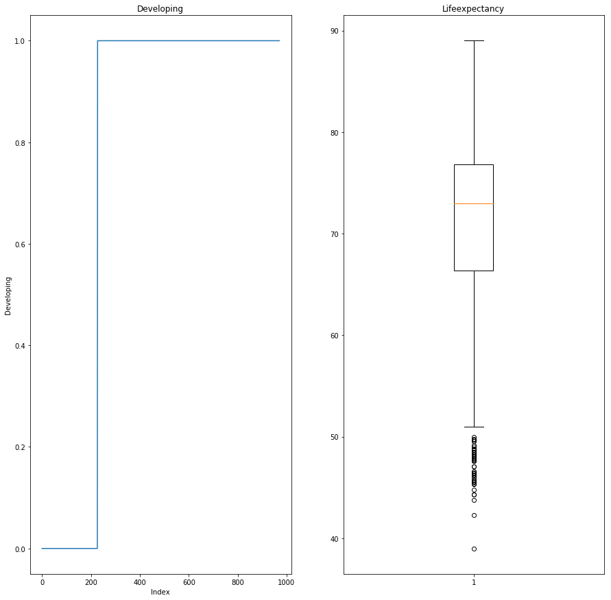

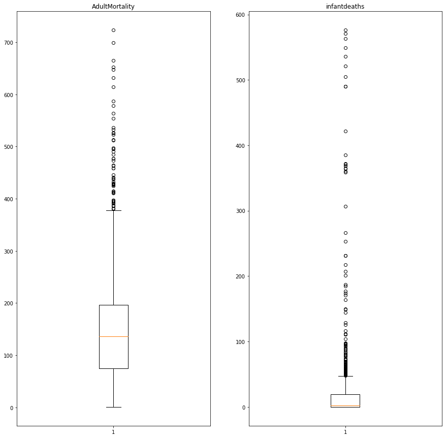

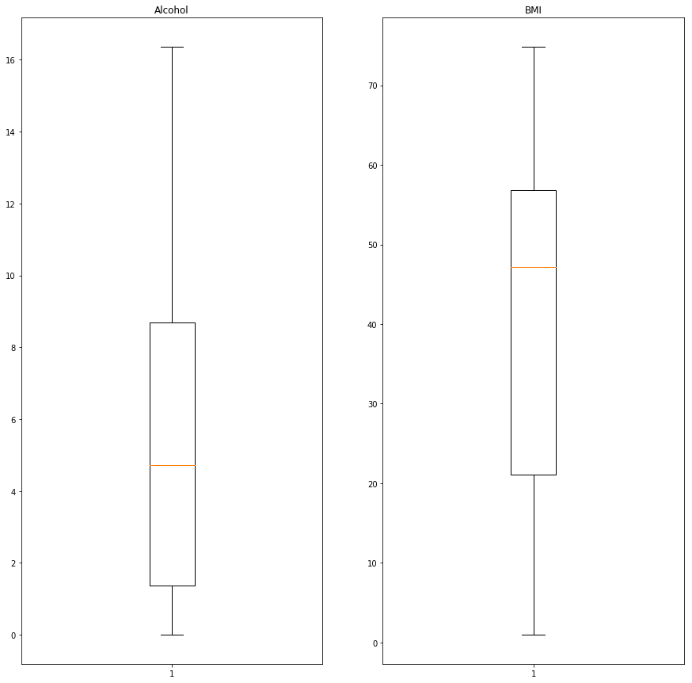

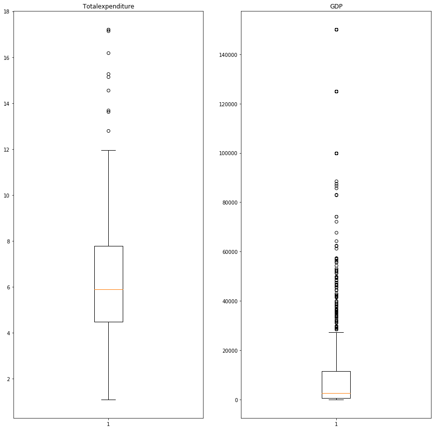

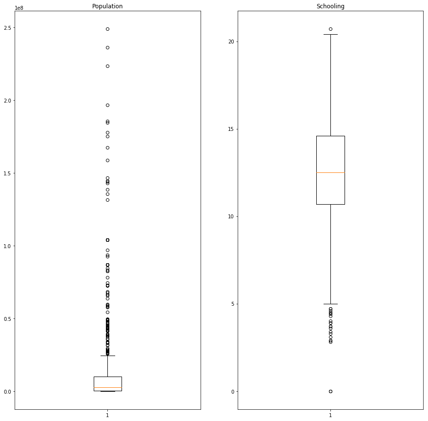

```python
#DeepCopy list
olympicLifeOutliners = cp.copy(olympicLifeCleaned)

#Showing graphs to find outliners
figure1 = plt.figure(figsize=(15,15))

olympicLifeOutliners = olympicLifeOutliners.sort_values(['Developing'])
olympicLifeOutliners.reset_index(inplace=True, drop=True)
plt.subplot(121)
plt.title('Developing')
plt.plot(olympicLifeOutliners['Developing'])
plt.xlabel('Index')
plt.ylabel('Developing')

olympicLifeOutliners = olympicLifeOutliners.sort_values(['Lifeexpectancy'])
olympicLifeOutliners.reset_index(inplace=True, drop=True)
plt.subplot(122)
plt.title('Lifeexpectancy')
plt.boxplot(olympicLifeOutliners['Lifeexpectancy'])

plt.figure(figsize=(15,15))

olympicLifeOutliners = olympicLifeOutliners.sort_values(['AdultMortality'])
olympicLifeOutliners.reset_index(inplace=True, drop=True)
plt.subplot(121)
plt.title('AdultMortality')
plt.boxplot(olympicLifeOutliners['AdultMortality'])

olympicLifeOutliners = olympicLifeOutliners.sort_values(['infantdeaths'])
olympicLifeOutliners.reset_index(inplace=True, drop=True)
plt.subplot(122)
plt.title('infantdeaths')
plt.boxplot(olympicLifeOutliners['infantdeaths'])

plt.figure(figsize=(15,15))

olympicLifeOutliners = olympicLifeOutliners.sort_values(['Alcohol'])
olympicLifeOutliners.reset_index(inplace=True, drop=True)
plt.subplot(121)
plt.title('Alcohol')
plt.boxplot(olympicLifeOutliners['Alcohol'])


olympicLifeOutliners = olympicLifeOutliners.sort_values(['BMI'])
olympicLifeOutliners.reset_index(inplace=True, drop=True)
plt.subplot(122)
plt.title('BMI')
plt.boxplot(olympicLifeOutliners['BMI'])


plt.figure(figsize=(15,15))

olympicLifeOutliners = olympicLifeOutliners.sort_values(['Totalexpenditure'])
olympicLifeOutliners.reset_index(inplace=True, drop=True)
plt.subplot(121)
plt.title('Totalexpenditure')
plt.boxplot(olympicLifeOutliners['Totalexpenditure'])


olympicLifeOutliners = olympicLifeOutliners.sort_values(['GDP'])
olympicLifeOutliners.reset_index(inplace=True, drop=True)
plt.subplot(122)
plt.title('GDP')
plt.boxplot(olympicLifeOutliners['GDP'])

plt.figure(figsize=(15,15))


olympicLifeOutliners = olympicLifeOutliners.sort_values(['Population'])
olympicLifeOutliners.reset_index(inplace=True, drop=True)
plt.subplot(121)
plt.title('Population')
plt.boxplot(olympicLifeOutliners['Population'])


olympicLifeOutliners = olympicLifeOutliners.sort_values(['Schooling'])
olympicLifeOutliners.reset_index(inplace=True, drop=True)
plt.subplot(122)
plt.title('Schooling')
plt.boxplot(olympicLifeOutliners['Schooling'])
plt.show()
```

# Exploratory Data Analysis

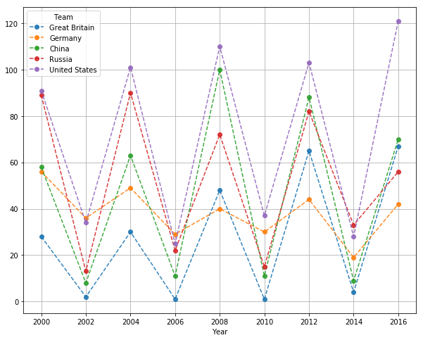

```python
medalsPerCountry = medalTableAfter2000.groupby('Team')['Medals'].sum().reset_index()
topCountries = medalsPerCountry.sort_values('Medals').tail().drop('Medals', axis = 1)
medalsPerYear = pd.pivot_table(medalTableAfter2000,
                              index = 'Year',
                              columns = 'Team',
                              values = 'Medals',
                              aggfunc = 'sum')[topCountries['Team']]


medalsPerYear.plot(linestyle = '--', marker = 'o', alpha = 0.9, figsize = (10,8), grid = True)
```

A view on the biggest Medal Winners.

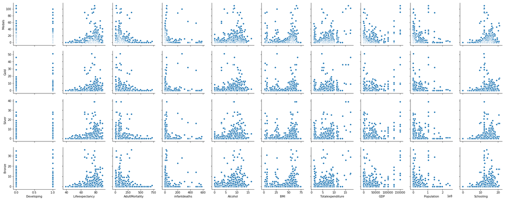

```python
sns.pairplot(data = olympicLifeCleaned,
             y_vars= ['Medals','Gold','Silver','Bronze'],
             x_vars= olympicLifeCleaned.columns[6:])
```

Plots each Medal to the Features. Here we see the distribution to all Medals are nearly the same.

As you can see in the pair plot, the data is quite scattered and therefore less suitable for regression. For this reason we choose for the Learners the two classifiers kNN and Random Forest.

```python
corr = olympicLifeCleaned.drop(columns = ['Year'])
corr = corr.corr()
corr = corr.loc['Developing':,'Gold':'Medals']
corr.style.background_gradient(cmap='coolwarm')
```

|  | Gold | Silver | Bronze | Medals |
| --- | --- | --- | --- | --- |
| Developing | -0.246591 | -0.298167 | -0.268181 | -0.279563 |
| Lifeexpectancy | 0.218202 | 0.258699 | 0.252672 | 0.250896 |
| AdultMortality | -0.159755 | -0.17286 | -0.162755 | -0.170834 |
| infantdeaths | 0.0898588 | 0.0294114 | 0.029103 | 0.0530674 |
| Alcohol | 0.268394 | 0.328718 | 0.324741 | 0.316717 |
| BMI | 0.10782 | 0.149627 | 0.151131 | 0.139896 |
| Totalexpenditure | 0.199665 | 0.204685 | 0.174026 | 0.199921 |
| GDP | 0.418552 | 0.450109 | 0.409002 | 0.440806 |
| Population | 0.208535 | 0.229384 | 0.206742 | 0.222283 |
| Schooling | 0.175374 | 0.243241 | 0.244925 | 0.227202 |

# Preprozessing

```python
#Deep Copy
cleanedData = cp.copy(olympicLifeCleaned)

#Drop Gold Silver Bronze Medallion
cleanedData = cleanedData.drop('Gold', axis=1)
cleanedData = cleanedData.drop('Silver', axis=1)
cleanedData = cleanedData.drop('Bronze', axis=1)
cleanedData = cleanedData.drop('Year', axis=1)

#Encode Country Strings
le = preprocessing.LabelEncoder()
cleanedData['Country'] = le.fit_transform(cleanedData['Country'])

#group by Country
#groupedData = cleanedData.groupby("Country").mean().round(0).astype('int')

#generate feature frame
X = cleanedData.drop('Medals', axis=1)
Y = cleanedData['Medals']

# Splits the Medalcount in groups 0/1-25/26-50/51-75/76-100/+100
df = pd.DataFrame(Y, columns=['Medals'])
for index, row in df.iterrows():
    if df.loc[index,'Medals'] == 0:
            df.loc[index,'Medals'] = 0
    elif df.loc[index,'Medals'] >= 1 and df.loc[index,'Medals'] <= 25:
            df.loc[index,'Medals'] = 1
    elif df.loc[index,'Medals'] >= 26 and df.loc[index,'Medals'] <= 50:
            df.loc[index,'Medals'] = 2
    elif df.loc[index,'Medals'] >= 51 and df.loc[index,'Medals'] <= 75:
            df.loc[index,'Medals'] = 3
    elif df.loc[index,'Medals'] >= 76 and df.loc[index,'Medals'] <= 100:
            df.loc[index,'Medals'] = 4
    elif df.loc[index,'Medals'] >= 101:
            df.loc[index,'Medals'] = 5

Y= df['Medals']
df = df.sort_values(['Medals'])

#Split data in 70% learn and 30% test data
X_train, X_test, y_train, y_test = train_test_split(X, Y, test_size=0.30, random_state=0)
```

# Random Forest

The Random Forest Classifier is a supervised learning algorithm. It uses multiple descicion trees so create the best.

We decided to use the random forest classification because it is quite easy to implement and well suited for our dataset.

## Creating and Training

```python
# Create a Random Forest Classifier
rf_clf=RandomForestClassifier(n_estimators=10, max_leaf_nodes=10, random_state=1,);

# Train Classifier
rf_clf.fit(X_train, y_train.tolist())

# Predict training data
y_rf_pred_train = rf_clf.predict(X_train)

# Predict testing data
y_rf_pred_test = rf_clf.predict(X_test)

# Model accuracy
print('Learned accuracy:')
print(accuracy_score(y_train, y_rf_pred_train))
print('Tested accuracy:')
print(accuracy_score(y_test, y_rf_pred_test))
```

```
Learned accuracy:
0.7540500736377025
Tested accuracy:
0.708904109589041
```

## Validation

```
Text(0.5,0,'Predicted label')
```

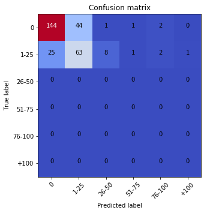

```python
cm = confusion_matrix(y_rf_pred_test, y_test)

plt.figure(figsize = (5,5))
plt.imshow(cm, interpolation='nearest', cmap="coolwarm")
plt.title('Confusion matrix')
classes = ['0','1-25','26-50','51-75','76-100','+100']
#plt.colorbar()
tick_marks = np.arange(len(classes))
plt.xticks(tick_marks, classes, rotation=45)
plt.yticks(tick_marks, classes)

thresh = cm.max() / 2.
for i, j in itertools.product(range(cm.shape[0]), range(cm.shape[1])):
    plt.text(j, i, format(cm[i, j], 'd'),
         horizontalalignment="center",
         color="white" if cm[i, j] > thresh else "black")

plt.ylabel('True label')
plt.xlabel('Predicted label')
```

## Furter view on importance

```
Text(0.5,0,'Importance in %')
```

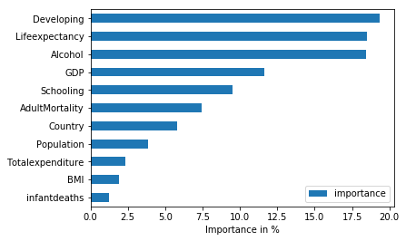

```python
figure = pd.DataFrame(np.round(rf_clf.feature_importances_*100, 2))
figure.columns = ['importance']
figure.index = ['Country','Developing', 'Lifeexpectancy', 'AdultMortality',
'infantdeaths', 'Alcohol', 'BMI', 'Totalexpenditure', 'GDP','Population',
'Schooling']
figure.sort_values('importance', inplace=True)

featfig = plt.figure(figsize=(10,10))
figure.plot.barh()
plt.xlabel("Importance in %")
```

# ADA-Boost

AdaBoost takes a weaker Classfifier (in this case random Forest), and trains it sequencell to accieve a better result with weighting.

## Creating and Training

```python
# Create a AdaBoost Classifier with the Random Forest Classifier
ada_clf = AdaBoostClassifier(rf_clf, n_estimators=2, algorithm="SAMME.R", learning_rate=1)

# Train Classifier
ada_clf.fit(X_train, y_train)

# Predict training data
y_ada_pred_train = ada_clf.predict(X_train)

# Predict testing data
y_ada_pred_test = ada_clf.predict(X_test)

#Model accuracy
print('Old trained accuracy:')
print(accuracy_score(y_train, y_rf_pred_train))
print('New trained accuracy:')
print(accuracy_score(y_train, y_ada_pred_train))
print('Old tested accuracy:')
print(accuracy_score(y_test, y_rf_pred_test))
print('New tested accuracy:')
print(accuracy_score(y_test, y_ada_pred_test))
```

```
Old trained accuracy:
0.7540500736377025
New trained accuracy:
0.7643593519882179
Old tested accuracy:
0.708904109589041
New tested accuracy:
0.702054794520548
```

## Improving

To find the best n_estimators value we can plot the staged score after each iteration of boosting

[figure not shown]

```python
ada_scores = [s for s in ada_clf.staged_score(X_test, y_test)]
plt.plot(ada_scores)
```

## Validation

```
Text(0.5,0,'Predicted label')
```

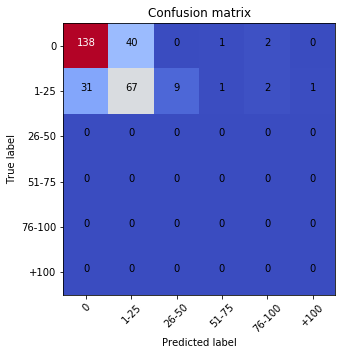

```python
cm = confusion_matrix(y_ada_pred_test, y_test)

plt.figure(figsize = (5,5))
plt.imshow(cm, interpolation='nearest', cmap="coolwarm")
plt.title('Confusion matrix')
classes = ['0','1-25','26-50','51-75','76-100','+100']
#plt.colorbar()
tick_marks = np.arange(len(classes))
plt.xticks(tick_marks, classes, rotation=45)
plt.yticks(tick_marks, classes)

thresh = cm.max() / 2.
for i, j in itertools.product(range(cm.shape[0]), range(cm.shape[1])):
    plt.text(j, i, format(cm[i, j], 'd'),
         horizontalalignment="center",
         color="white" if cm[i, j] > thresh else "black")

plt.ylabel('True label')
plt.xlabel('Predicted label')
```

# KNN LEARNER

The KNN algorithm (k-nearest neighbors) is an easy to implement, supervised algorithm for machine learning. The KNN algorithm is based on the assumption that similar things exist in close proximity. In short, similar things are close to each other.

## Find best K

To Find the best K we start with a random k. In this case 5.

```python
# Create a K-Nearest Neighbors Classifier
knn_clf_test = KNeighborsClassifier(n_neighbors=5)

# Train Classifier
knn_clf_test.fit(X_train, y_train)

# Predict training data
y_knn_pred_train_test = knn_clf_test.predict(X_train)

# Predict testing data
y_knn_pred_test_test = knn_clf_test.predict(X_test)

# Model accuracy
print('Learned accuracy:')
print(accuracy_score(y_train, y_knn_pred_train_test))
print('Tested accuracy:')
print(accuracy_score(y_test, y_knn_pred_test_test))
```

```
Learned accuracy:
0.7025036818851251
Tested accuracy:
0.5787671232876712
```

Were looping between 1 and 40 Neigthbours and calclulate the prediction, store and show them to get a view about the best Neigthbour count.

To generate an perfect learner were using `sklearn` die `GridSearchCB` - libaries.

Searching the parameters using `GridSearchCV` takes a while, but then calculating the classification is very fast.

```
Figure(864x432)
Fitting 3 folds for each of 116 candidates, totalling 348 fits
```

```
[Parallel(n_jobs=-1)]: Done  34 tasks      | elapsed:   12.5s
[Parallel(n_jobs=-1)]: Done 348 out of 348 | elapsed:   12.9s finished
```

```
Score:	0.6082474226804123
Estimator:	KNeighborsClassifier(algorithm='auto', leaf_size=30, metric='euclidean',
           metric_params=None, n_jobs=1, n_neighbors=2, p=2,
           weights='uniform')
Params:	{'metric': 'euclidean', 'n_neighbors': 2, 'weights': 'uniform'}
```

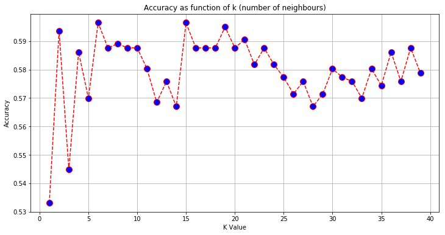

```python
crossAccuracyList = []
accuracyList = []


# Calculating error for K values between 1 and 40
for i in range(1, 40):
    knn = KNeighborsClassifier(n_neighbors=i)
    knn.fit(X_train, y_train)
    y_knn_pred_train = cross_val_predict(knn, X_train, y_train, cv=7)
    y_knn_pred_test = knn.predict(X_test)
    crossAccuracyList.append(accuracy_score(y_train, y_knn_pred_train))
    accuracyList.append(accuracy_score(y_train, y_knn_pred_train))


figure = plt.figure(figsize=(12, 6))
plt.plot(range(1, 40), accuracyList, color='red', linestyle='dashed', marker='o',
         markerfacecolor='blue', markersize=10, label='accuracy')
plt.title('Accuracy as function of k (number of neighbours)')
plt.xlabel('K Value')
plt.ylabel('Accuracy')
plt.grid(True)
print(figure)

grid_params = {
    'n_neighbors': np.arange(1,30,1),
    'weights': ['uniform','distance'],
    'metric':['euclidean','manhattan']
}

gs = GridSearchCV(KNeighborsClassifier(),
                 grid_params,
                 verbose = 1,
                 cv = 3,
                 n_jobs = -1)
gs_results = gs.fit(X_train, y_train)

print('Score:\t{}'.format(gs_results.best_score_))
print('Estimator:\t{}'.format(gs_results.best_estimator_))
print('Params:\t{}'.format(gs_results.best_params_))
```

## Creating and Training

```python
# Create a K-Nearest Neighbors Classifier
knn_clf = KNeighborsClassifier(algorithm='auto', leaf_size=30, metric='euclidean',
           metric_params=None, n_jobs=1, n_neighbors=2, p=2,
           weights='uniform')

# Train Classifier
knn_clf.fit(X_train, y_train)

# Predict training data
y_knn_pred_train = knn_clf.predict(X_train)

# Predict testing data
y_knn_pred_test = knn_clf.predict(X_test)

# Model accuracy
print('Learned accuracy:')
print(accuracy_score(y_train, y_knn_pred_train))
print('Tested accuracy:')
print(accuracy_score(y_test, y_knn_pred_test))
```

```
Learned accuracy:
0.7628865979381443
Tested accuracy:
0.5958904109589042
```

## Validation

```
Text(0.5,0,'Predicted label')
```

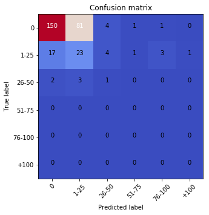

```python
cm = confusion_matrix(y_knn_pred_test, y_test)

plt.figure(figsize = (5,5))
plt.imshow(cm, interpolation='nearest', cmap="coolwarm")
plt.title('Confusion matrix')
classes = ['0','1-25','26-50','51-75','76-100','+100']
#plt.colorbar()
tick_marks = np.arange(len(classes))
plt.xticks(tick_marks, classes, rotation=45)
plt.yticks(tick_marks, classes)

thresh = cm.max() / 2.
for i, j in itertools.product(range(cm.shape[0]), range(cm.shape[1])):
    plt.text(j, i, format(cm[i, j], 'd'),
         horizontalalignment="center",
         color="white" if cm[i, j] > thresh else "black")

plt.ylabel('True label')
plt.xlabel('Predicted label')
```

# Voting

Each of the classification algorithms generates its predictions. This allows us to apply the majority votes principle and take the prediction that fits best.

## Creating and Training

```python
# Create a Voting Classifier
vot_clf = VotingClassifier(estimators=[('ada', ada_clf),('kNN',knn_clf)],voting='soft')

# Train Classifier
vot_clf.fit(X_train,y_train)

# Predict training data
y_vot_pred_train = vot_clf.predict(X_train)

# Predict testing data
y_vot_pred_test = vot_clf.predict(X_test)

# Model accuracy
print('Learned accuracy:')
print(accuracy_score(y_train, y_knn_pred_train))
print('Tested accuracy:')
print(accuracy_score(y_test, y_knn_pred_test))
```

```
Learned accuracy:
0.7628865979381443
Tested accuracy:
0.5958904109589042
```

## Validation

```
Text(0.5,0,'Predicted label')
```

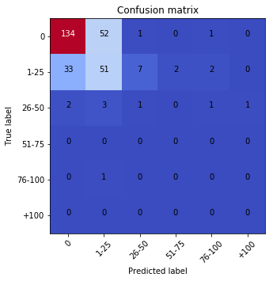

```python
cm = confusion_matrix(y_vot_pred_test, y_test)

plt.figure(figsize = (5,5))
plt.imshow(cm, interpolation='nearest', cmap="coolwarm")
plt.title('Confusion matrix')
classes = ['0','1-25','26-50','51-75','76-100','+100']
#plt.colorbar()
tick_marks = np.arange(len(classes))
plt.xticks(tick_marks, classes, rotation=45)
plt.yticks(tick_marks, classes)

thresh = cm.max() / 2.
for i, j in itertools.product(range(cm.shape[0]), range(cm.shape[1])):
    plt.text(j, i, format(cm[i, j], 'd'),
         horizontalalignment="center",
         color="white" if cm[i, j] > thresh else "black")

plt.ylabel('True label')
plt.xlabel('Predicted label')
```

# Swiss Medals 2020

```python
d = {'col1': [122], 'col2': [0],'col3': [83], 'col4': [37],'col5': [0], 'col6': [1.67],'col7': [22], 'col8': [1.5],'col9': [80000], 'col10': [8500000],'col11': [13]}
swissMedals = pd.DataFrame(data=d)

swissMedals_pred = vot_clf.predict(swissMedals)
print(swissMedals_pred)
```

```
[1.]
```

# Conclusion

## Data

Most of the problems were caused by the `LifeExpectancy` dataset, because it was incomplete. For example, the USA lacked GDP and population. These data were however very important for the course of the project, since the USA played mostly at the front of the medal table. Beside the missing data, we dont completly trust the dataset. For example Estonia had some Years of really high and low Alcohol consumption.

## Classifier

The work with the different Learner was however simpler. Python offers many possibilities and everything is documented in detail.

The accuracy of our learners are relatively good. In the confusion matrix we can see that the learners works well with a few medals. On higher medal counts however he is no longer so reliable. The reason for this is that most countries have not won any medals and only a few countries have won more than 30 Medals. As a result, the learner has too little data to make a reliable decision if he has won several medals.

## Project

The MachineLearning project was very exciting because you could select the data set yourself. So you could choose a topic that you found interesting. With the Olympiad dataset we had a huge selection of possibilities.

We are satisfied with our project because we were able to apply and consolidate the content of the contact lesson and we got an acceptable result.

And we will win some Medals in the Future :D